# POLS 2972Q

Quantitative Analysis in Political Science

Lecture 21 |

Quantifying Uncertainty

## Plan for Today

- Hypothesis Testing Intuition
  - Null Hypothesis
  - Alternative Hypothesis
  - Test Statistic
  - P-Values

## The Context

- Suppose we are analyzing data from a randomized experiment for the purpose of estimating the average causal effect of a treatment on an outcome
- In this context, X is
  - The treatment variable
- Y is
  - The outcome variable
- What do we need to calculate to estimate the average causal effect?
  - Difference in means estimator
- If we want to compute it by fitting a linear model:
  - $\hat{Y}=\hat{\alpha}+\hat{\beta}X$
- What we can estimate is $\hat{\beta}$, which is the average causal effect at the sample level
- What we care about is B, which is the true average causal effect at the population level
- As we discussed in the last class, sample statistics often differ from population parameters because of the noise produced by sampling variability so we cannot assume that $\hat{\beta}$ equals B
- The question we would like to answer is: Looking at the sample data, do we have enough evidence to say that there is an average casual effect at the population level different than zero?
  - In other words, can we say that B is not likely to be zero?
    - To answer this question, we need to do hypothesis testing

## Hypothesis Testing

- Methodology based on proof by contradiction: We start by assuming the contrary of what we would like to prove and show how this assumption leads to a logical contradiction
- In this class, we will use hypothesis testing to determine whether B, that is, the true average causal effect at the population level, is likely to be different than zero
- We set the **null hypothesis** to state that B is zero:
  - $H_0:B=0$
- We set the **alternative hypothesis** to state that B is either positive or negative (i.e., a two-sided alternative hypothesis):
  - $H_1:B\neq 0$
- Thanks to the Central Limit Theorem, we know that if $H_0$ is true, then the test-statistic over multiple samples:

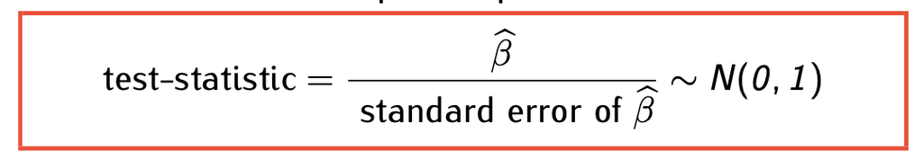

- That is, if we were to draw multiple large samples from the same target population, calculate $\hat{\beta}$ and the standard error of $\hat{\beta}$ each time, then the multiple test statistics would be distributed as a standard normal distribution

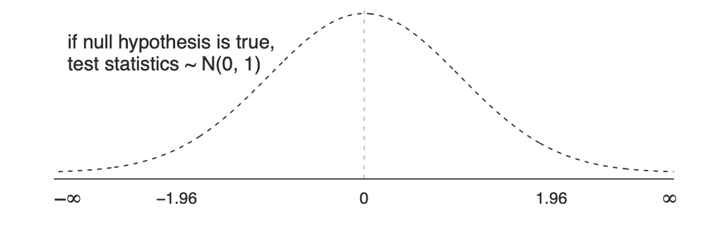

- In reality, we only draw one sample, so we won’t be able to observe the distribution of test statistics
  - We only observe one test statistic: $Z^{obs}$
- Since we know the distribution of the test statistics under the null (if the null hypothesis is true), we can calculate the probability that we observe a test statistic as extreme or more extreme as the one we do observe if $H_0$ is true
  - This is known as the **p-value**: $P(Z \leq - |Z^{obs}| + P(Z\geq|Z{obs}|$)

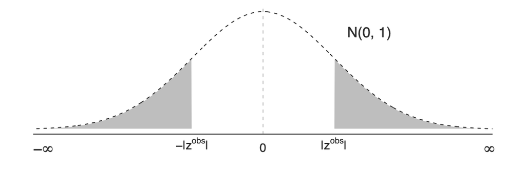

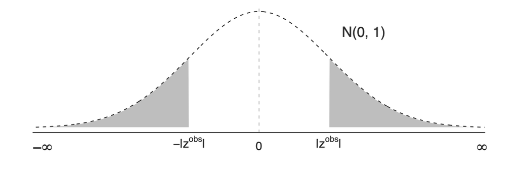

- **If the p-value is large**: the probability that we observe $Z^{obs}$ or more extreme is large if $H_0$ is true
  - $Z^{obs}$ is common relative to the distribution of the test statistics under the null
  - Our evidence is consistent with $H_0$ being true
- Conclusion: We fail to reject $H_0$ and conclude the average causal effect is not statistically significant (we cannot statistically distinguish B from zero)

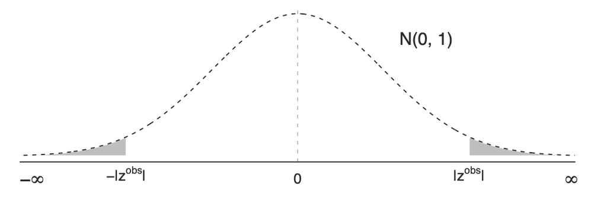

- **If the p-value is small**: the probability that we observe $Z^{obs}$ or more extreme is small if $H_0$ is true
  - $Z^{obs}$ is extreme relative to the distribution of test statistics under the null
  - Our evidence is inconsistent with $H_0$ being true (either $H_0$ is not true or we got unlucky by drawing a fringe sample)
- Conclusion: We reject $H_0$ and conclude the average causal effect is statistically significant (we can statistically distinguish B from zero)
- How small does the p-value need to be for us to reject the null hypothesis
  - Social scientists conventionally use one of three significance levels:
    - 10%, 5%, 1%
    - In general we use 5%, which we will use in this class

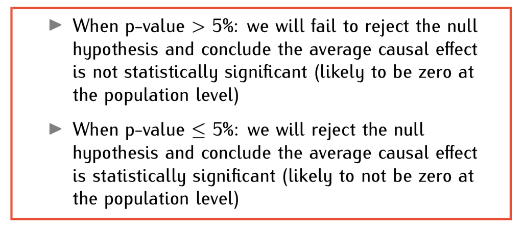

## Shortcut

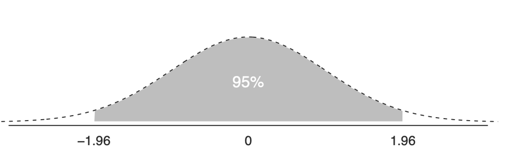

- Recall: $P(-1.96 \leq Z \geq 1.96) \approx 0.95$
  - So the probability that Z takes a value less than or equal to -1.96 plus the probability that Z takes a value greater than or equal to 1.96 is approximately 5%

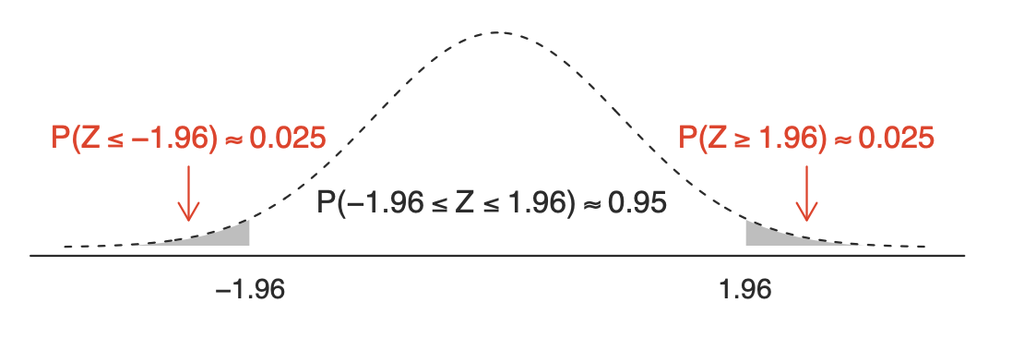

## Hypothesis Testing

- Specify null and alternative hypotheses
  - $H_0:B=0$ (The true average causal effect at the population level is zero)
  - $H_1:B\neq0$ (The true average causal effect at the population level is either positive or negative)
- Compute observed value of the test statistics and (perhaps also) the associated p-value
  - $Z^{obs} = \frac{\hat{\beta}}{standard \ error \ of \ \hat{\beta}}$
  - p-value = 2 $\times$ $P(Z\leq-|Z^{obs}|)$

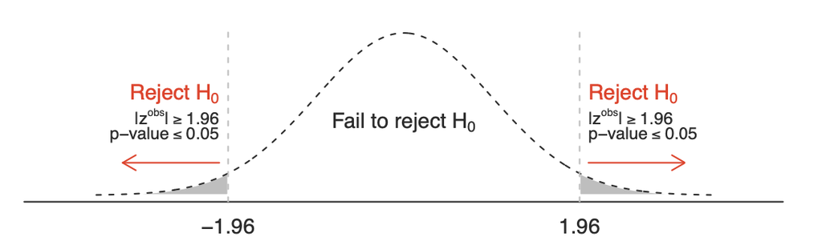

- Conclude
  - If $|Z^{obs}|$ < 1.96 or p-value > 0.05, fail to reject the null hypothesis and conclude the average causal effect is not statistically significant
  - If $|Z^{obs}|$ $\geq$ 1.96 or p-vale $\leq$ 0.05, reject the null hypothesis and conclude the average causal effect is statistically significant

## The Importance of Replication

- When an effect is statistically significant at the 5% level, do we know for sure that the true value of the average causal effect at the population level is not zero?
  - No
- A p-value of 5% does not rule out the possibility that the average causal effect is zero
- Thanks to CLT, we know that if the null hypothesis is true, in 5% of the samples drawn from the target population, we will wrongly reject the null when using a significance level of 5%
- It is important to replicate social scientific studies to confirm that we arrive at similar conclusions when analyzing a different sample from the same target population
- While the probability of falsely rejecting the null hypothesis in any one sample is 5%, the probability of falsely rejecting the null twice in a row, when analyzing two independent samples of data drawn from the same target population, is only 0.25%